# Food at College

## My Kruskal Wallis Analysis

```r
# From your file menu (at the top of R-Studio) select:
# "Session -> Set working directory -> To source file location"
# Then play this chunk to get the data into R.
library(mosaic)
library(car)
library(DT)
library(pander)
library(dplyr)
library(readr)
library(tidyverse)
# Load the food dataset
food <- read.csv("/Users/maiafaith/Downloads/Statistics-Notebook-master/food.csv")

food_clean <- food %>%
  filter(!is.na(GPA), !is.na(breakfast)) %>%
  mutate(
    GPA = as.numeric(GPA),
    breakfast = as.factor(breakfast),
    gender = as.factor(gender)
  )
```

### Hypotheses

**ANOVA** Null Hypothesis (𝐻0): All group means of GPA across breakfast consumption levels are equal.

Alternative Hypothesis (𝐻𝑎): At least one of the group means of GPA is different.

**Kruskal-Wallis** Null Hypothesis (𝐻0): The median GPA is the same across breakfast consumption groups.

Alternative Hypothesis (𝐻𝑎): The median GPA differs across breakfast consumption groups.

### Numerical and Graphical Summaries

```r
numeric_summary <- food_clean %>%
  group_by(breakfast) %>%
  summarise(
    GPA_mean = mean(GPA, na.rm = TRUE),
    GPA_sd = sd(GPA, na.rm = TRUE),
    Count = n()
  )
pander::pander(numeric_summary, caption = "Summary of GPA by Breakfast Consumption")
```

Summary of GPA by Breakfast Consumption

| breakfast | GPA_mean | GPA_sd | Count |
| --- | --- | --- | --- |
| Cereal | 3.425 | 0.3957 | 110 |
| Donut | 3.364 | 0.3482 | 13 |

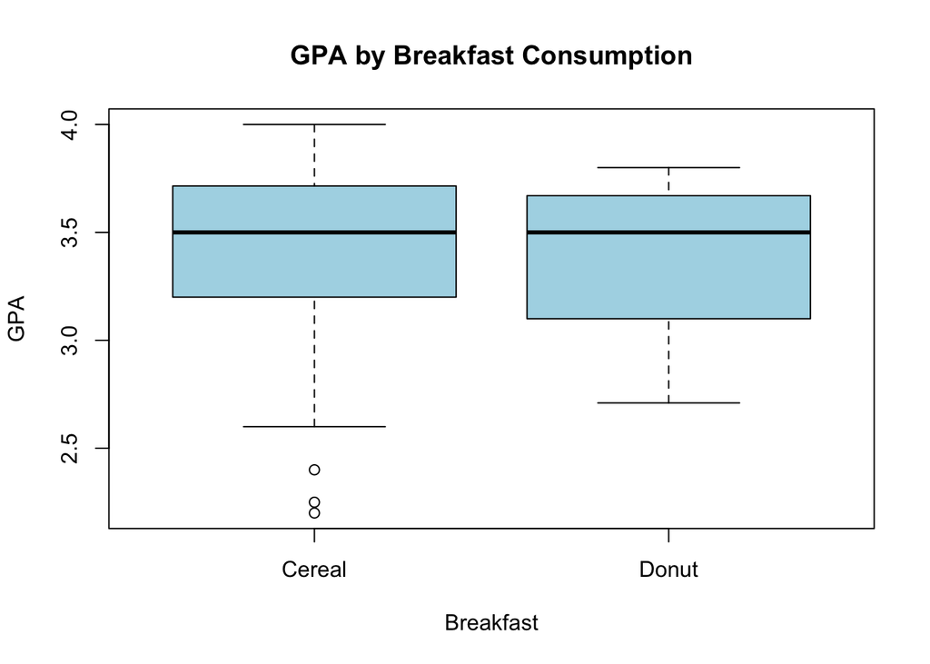

```r
boxplot(GPA ~ breakfast, data = food_clean,
        main = "GPA by Breakfast Consumption",
        xlab = "Breakfast",
        ylab = "GPA",
        col = "lightblue")
```

### ANOVA

```r
anova_model <- aov(GPA ~ breakfast, data = food_clean)
summary(anova_model)
```

```
##              Df Sum Sq Mean Sq F value Pr(>F)
## breakfast     1  0.044 0.04375   0.286  0.594
## Residuals   119 18.208 0.15301
## 2 observations deleted due to missingness
```

Interpretation: The ANOVA results suggest no significant effect of breakfast consumption on GPA (𝑝=0.594).

### Check ANOVA Assumptions

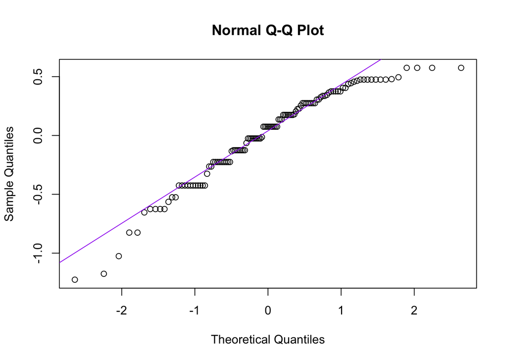

```r
# Normality Check
qqnorm(resid(anova_model))
qqline(resid(anova_model), col = "purple")
```

```r
# Homogeneity of Variances
leveneTest(GPA ~ breakfast, data = food_clean, center = "median")
```

```
## Levene's Test for Homogeneity of Variance (center = "median")
##        Df F value Pr(>F)
## group   1  0.3828 0.5373
##       119
```

Homogeneity of Variance: The test suggests that the variances of GPA across breakfast groups are approximately equal, meeting the assumption for conducting ANOVA. This means we can proceed with the one-way ANOVA analysis without concerns about violating the homogeneity of variance assumption.

### Kruskal Wallis Test

```r
kruskal_result <- kruskal.test(GPA ~ breakfast, data = food_clean)
print(kruskal_result)
```

```
##
##  Kruskal-Wallis rank sum test
##
## data:  GPA by breakfast
## Kruskal-Wallis chi-squared = 0.49068, df = 1, p-value = 0.4836
```

The Kruskal-Wallis test corroborates the earlier ANOVA result, indicating that breakfast consumption does not have a statistically significant impact on GPA in this dataset.

### Conclusion

Null Hypothesis (𝐻0): The median GPA is the same across the breakfast consumption groups.

Alternative Hypothesis (𝐻𝑎): The median GPA differs across the breakfast consumption groups. Since the p-value (0.4836) is greater than 0.05 (common significance level), we fail to reject the null hypothesis. This means:

The one-way ANOVA suggests no significant effect of breakfast consumption on GPA (p=0.594). The Kruskal-Wallis test corroborates this finding, showing no significant difference in GPA medians (p=0.4836).

For a future study, it may be beneficial to include other factors in the model like study time, sleep patterns. It would also be beneficial to increase the sample size.